# Manuscript draft

Molly Wilson

Dec. 2018

# 1 Intro + motivation

- Grazing by herbivorous fish is an established driver of coral reef health/dynamics
- As reefs become increasingly degraded/threatened, there is growing interest in understanding how much herbivory is needed to sustain coral reef health (e.g Karr et al., McClanahan et al.)
- However, not all herbivores are the same in terms of their grazing impact…
  - Recent developments in functional classifications, difference across species in terms of selectivity, etc. (e.g. Adam et al. 2018)
- In addition to these inter-species differences in functional role, differences in herbivore behavior also affect grazing impact and may drive variation in herbivore function among individuals or across reef systems
- Herbivore behavior has been shown to be impacted by…
  - Predator presence (Catano, Madin)
  - Presence of other herbivores (Gil)
  - Resource availability (Carlson, Tootell)
- But there is vary limited data on how herbivore feeding behaviors might vary across reef systems, as well as the environmental factors associated with grazing differences
- Here we document variability in multiple components of scarid feeding behavior across reef sites in three Caribbean islands and explore/enhance our understanding of potential underlying drivers

# 2 Methods

## 2.2 Analysis

# 3 Results

## 3.1 Variation in feeding rate across benthic and fish community variables

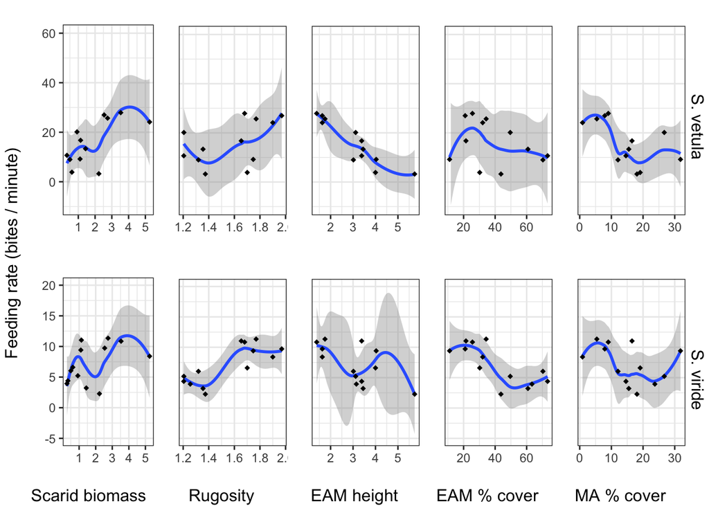

## 3.2 Variation in feeding intensity across benthic and fish community variables

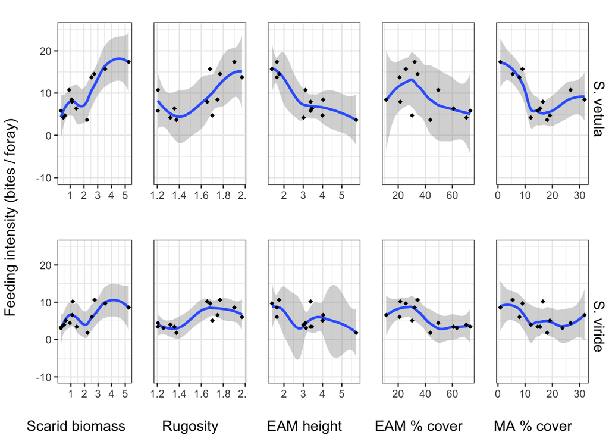

## 3.3 PCA

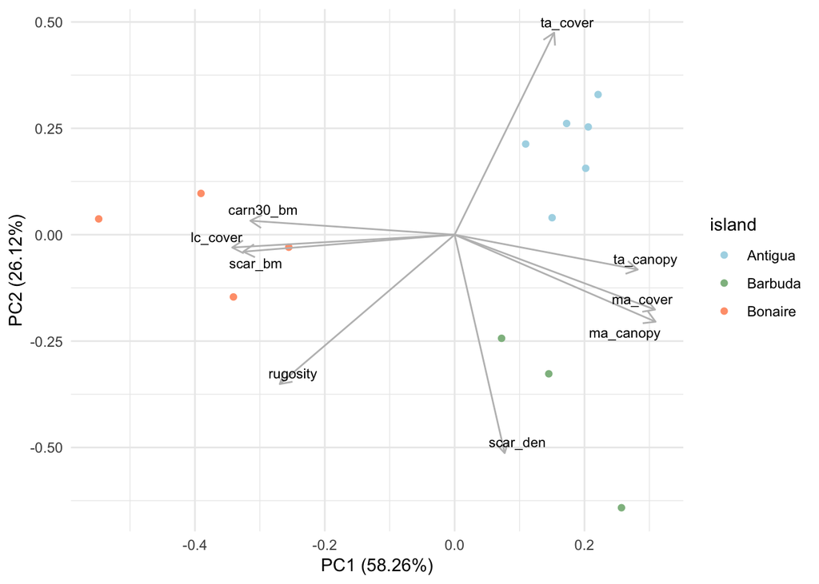

## 3.4 GAMM results

```
##
## Family: gaussian
## Link function: identity
##
## Formula:
## fr_mean ~ species_code + phase + s(length_m, by = factor(species_code)) +
##     s(pc1_all, by = factor(species_code)) + s(pc2_all)
##
## Parametric coefficients:
##                  Estimate Std. Error t value Pr(>|t|)
## (Intercept)       1012.28     167.69   6.037 6.41e-07 ***
## species_codestop  -411.27      60.92  -6.751 7.29e-08 ***
## phaset            -319.03     113.20  -2.818  0.00782 **
## ---
## Signif. codes:  0 '***' 0.001 '**' 0.01 '*' 0.05 '.' 0.1 ' ' 1
##
## Approximate significance of smooth terms:
##                                        edf Ref.df     F p-value
## s(length_m):factor(species_code)qup  3.782  3.782 2.817  0.0247 *
## s(length_m):factor(species_code)stop 1.000  1.000 3.284  0.0782 .
## s(pc1_all):factor(species_code)qup   2.526  2.526 3.057  0.0413 *
## s(pc1_all):factor(species_code)stop  1.000  1.000 0.610  0.4398
## s(pc2_all)                           1.000  1.000 1.025  0.3181
## ---
## Signif. codes:  0 '***' 0.001 '**' 0.01 '*' 0.05 '.' 0.1 ' ' 1
##
## R-sq.(adj) =  0.526
##   Scale est. = 37971     n = 48
```

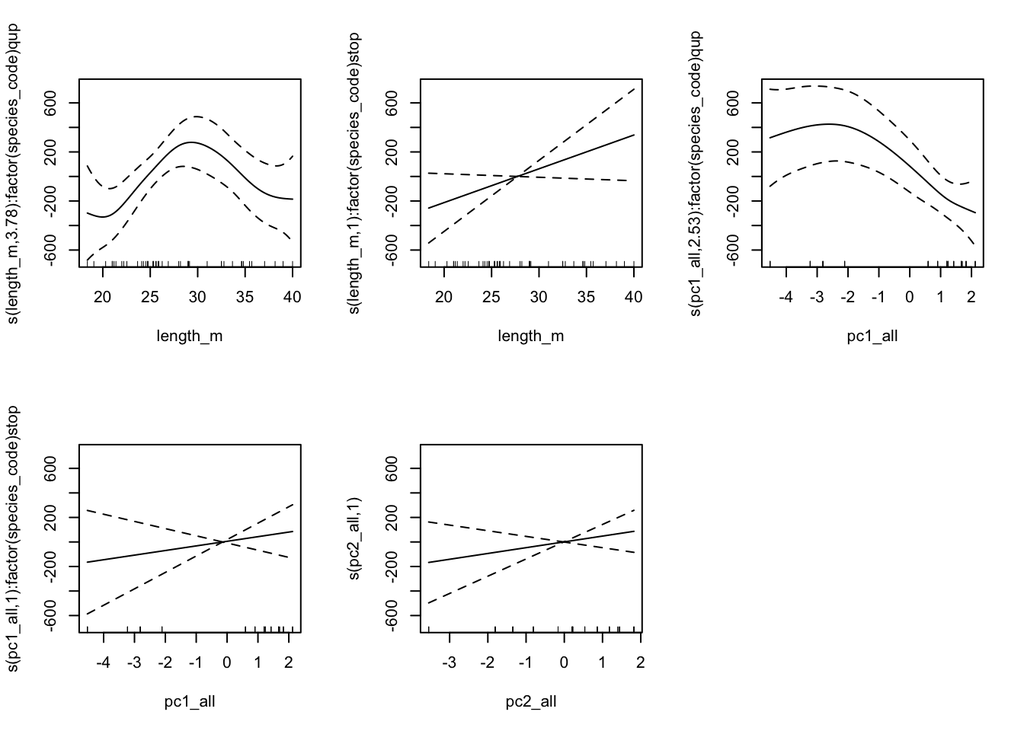

# 4 Discussion

- GAMM results: explain meaning/significance of PC1. *S. vetula* seem more impacted by PC1 than *S. viride*
- Potential mechanisms/hypotheses for these observed trends:
  - Social feeding hypothesis: more time must be spent vigilant in smaller groups, potential compounding effect with overfishing/loss of herbivory
  - Nutrient limitation hypothesis: scarids must graze more (and more intensely) in sites with lower algal canopy heights and percent cover
  - Predation risk hypothesis: presence of large piscivores does not explain feeding trends, but risk from spearfishers may play a bigger role (able to target larger fish, i.e. those sampled here). (Incorporate rugosity here?)
- Caveats + limitations: all these different factors are understandablycorrelated in observational work
  - room for experimental work to unpack/distinguish drivers
  - room (/need) for incorporation of behavior in coral reef grazing models, especially those used to set targets for minimum herbivore biomass levels, because these may look very different in different reef conditions.
- Conservation + mgmt implications: multiple human impacts on reefs may affect herbivore behavior in different ways, spec. fishing + habitat degradation - which may have reinforcing/compounding negative effects on reef health